# STSCI 4630 - Spring 2019 - HW2

Da (Harry) Lu, dl947

Due Tuesday, Feb/12/2019

# Question 1

> [10 points] Run lines 1 to 5. Adapt lines 6 and 7 to produce a normal probability plot for Goldman Sachs (GS). Submit your normal probability plot. What does the plot suggest about the distribution of the returns compared to the normal distribution. Justify your answer briefly.

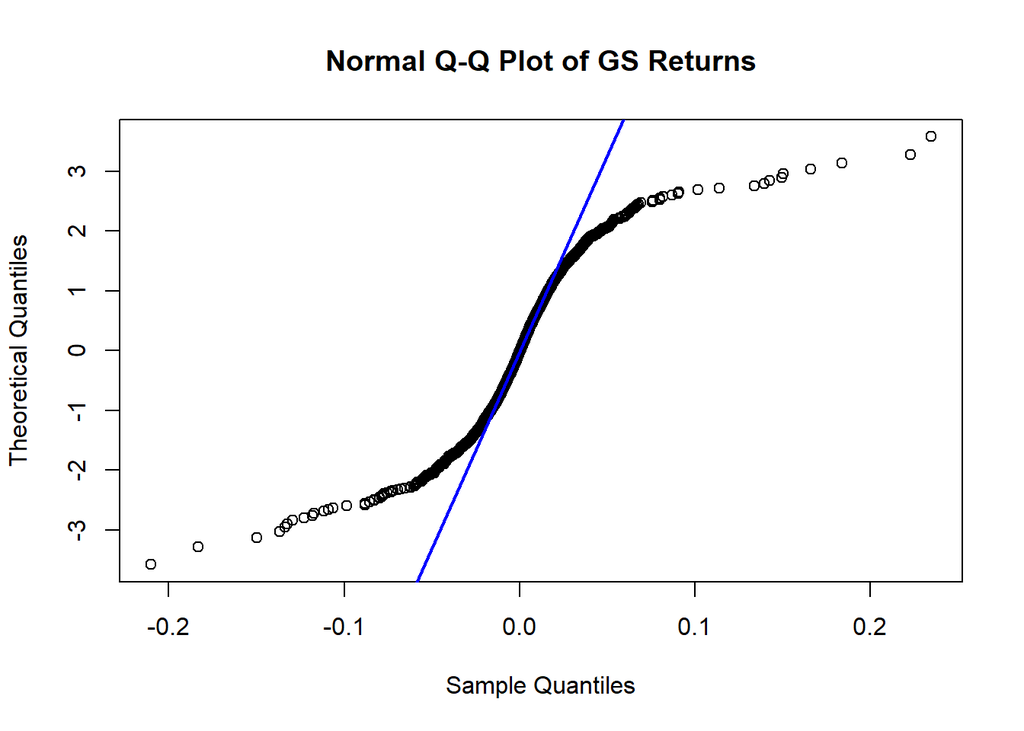

```r
qqnorm(Returns$GS,datax=TRUE,main="Normal Q-Q Plot of GS Returns")
qqline(Returns$GS,datax=TRUE,col="blue",lwd=2)
```

The distribution of the GS returns cannot be treated as a normal distribution because the two tails deviate from the qqline quite far.

# Question 2

> [10 points] By adapting lines 8 to 11, find the sample standardized skewness and the sample standardized kurtosis for the returns for Goldman Sachs (GS). Submit your output. What do these moments suggest about the distribution of the returns compared to the normal distribution? Justify your answer briefly.

```r
#install.packages("moments")
library(moments)
skewness(Returns$GS)
```

```
## [1] 0.2767769
```

```r
kurtosis(Returns$GS)
```

```
## [1] 18.61229
```

The GS returns have skewness about $0$ and kurtosis of $19$.

The normal distribution has skewness of $0$ and kurtosis of $3$, so the GS returns does not follow the normal distribution.

# Question 3

> [10 points] Perform the Shapiro-Wilk test and the Jarque-Bera test for the returns for Goldman Sachs (GS) by adapting lines 12 and 13. Submit your output. What are the p-values from the test? What do you conclude from the tests? Justify your answer briefly.

```r
shapiro.test(Returns$GS)
```

```
##
##  Shapiro-Wilk normality test
##
## data:  Returns$GS
## W = 0.8543, p-value < 2.2e-16
```

```r
jarque.test(Returns$GS)
```

```
##
##  Jarque-Bera Normality Test
##
## data:  Returns$GS
## JB = 29764, p-value < 2.2e-16
## alternative hypothesis: greater
```

Both p-values approximate to 0, so we reject $H_0$ (returns are normally distributed). The results show that the GS returns are not normally distributed.

# Question 4

> [15 points] By adapting lines 14 to 19, prepare a histogram for the returns for Goldman Sachs (GS) with a matching normal density curve superimposed. Submit your histogram. What is the mean of the matching normal distribution? What is the standard deviation of the matching normal distribution?

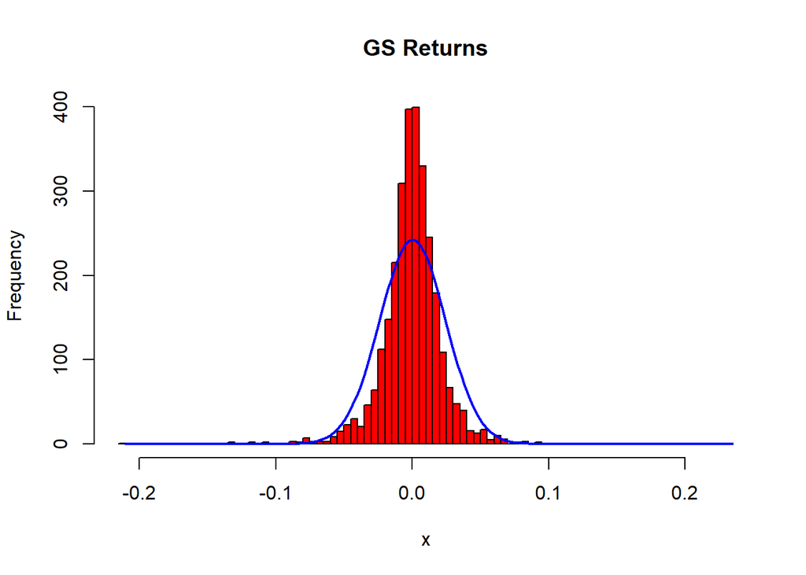

```r
x=Returns$GS
h=hist(x,breaks=100,col="red",main="GS Returns")
xfit=seq(min(x),max(x),length=200)
yfit=dnorm(xfit,mean=mean(x),sd=sd(x))
yfit=yfit*diff(h$mids[1:2])*length(x)
lines(xfit,yfit,col="blue",lwd=2)
```

```r
mean(x)
```

```
## [1] 0.0002317852
```

```r
sd(x)
```

```
## [1] 0.02408091
```

The mean of the GS returns is 0.00023 and the standard deviation of the GS returns is 0.02408.

# Question 5

> [20 points] By adapting lines 20 to 23, fit a location-scale Student’s t-distribuion to the returns for Goldman Sachs (GS). Submit your output.

```r
#install.packages("MASS")
library(MASS)
fit=fitdistr(Returns$GS,"t")
fit
```

```
##         m              s              df
##   0.0005273569   0.0133452040   2.7340473894
##  (0.0003051133) (0.0003283650) (0.1609371218)
```

> 1. What is the maximum likelihood estimate of the location parameter?

```r
fit$estimate[1]
```

```
##            m
## 0.0005273569
```

> 2. What is the maximum likelihood estimate of the scale parameter?

```r
fit$estimate[2]
```

```
##         s
## 0.0133452
```

> 3. What is the maximum likelihood estimate of the degrees of freedom?

```r
fit$estimate[3]
```

```
##       df
## 2.734047
```

> 4. What is the standard error for estimate of the degrees of freedom?

```r
fit$sd[3]
```

```
##        df
## 0.1609371
```

> 22. Give a 95% confidence interval for the degrees of freedom.

```r
upper=fit$estimate[3]+1.96*fit$sd[3]
lower=fit$estimate[3]-1.96*fit$sd[3]
```

The 95% confidence interval is (2.4186106, 3.0494841).

> 6. What is the mean of the fitted location-scale Student’s t-distribution?

```r
fit$estimate[1]
```

```
##            m
## 0.0005273569
```

> 7. What is the standard deviation of the fitted location-scale Student’s t-distribution?

$$\text{s}\times\sqrt{\frac{\text{df}}{\text{df}-2}}$$

```r
s=fit$estimate[2]
df=fit$estimate[3]
result=s*sqrt(df/(df-2))
result
```

```
##          s
## 0.02575527
```

The standard deviation is 0.0257553.

# Question 6

> [10 points] By adapting lines 24 to 29 and using your results from question 5, prepare a t-probability plot for the returns for Goldman Sachs (GS). Submit your plot. Based on the plot, do the returns appear to follow a location-scale Student’s t-distribution? Justify your answer briefly.

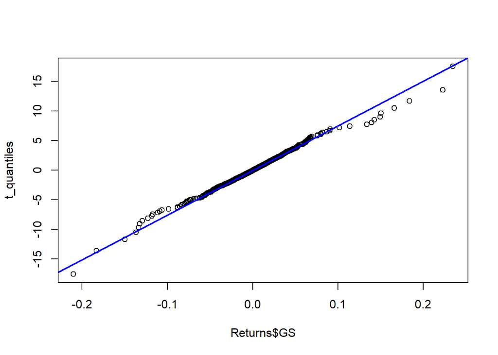

```r
degf=fit$estimate[3]
n=length(Returns$GS)
t_quantiles=qt((1:n)/(n+1),df=degf)
qqplot(Returns$GS, t_quantiles)
line=lm(qt(c(0.25,0.75),df=degf)~quantile(Returns$GS,c(0.25,0.75)))
abline(line,col="blue",lwd=2)
```

The plot of returns is very close to the line, so that the returns appear to follow a location-scale Student’s t-distribution.

# Question 7

> [10 points] By adapting lines 30 to 38, prepare a histogram of the returns from Goldman Sachs (GS) with the fitted location-scale Student’s t-distribution from your answer to question 5 superimposed. Submit your histogram.

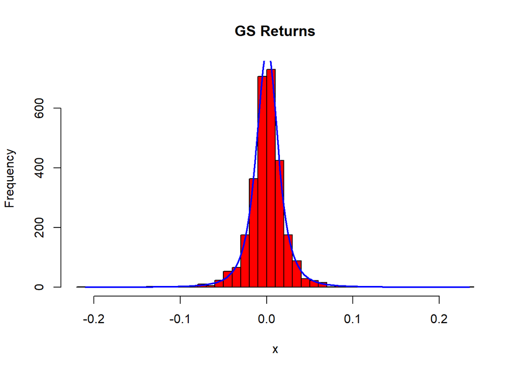

```r
x=Returns$GS
degf=fit$estimate[3]
m=fit$estimate[1]
s=fit$estimate[2]
h=hist(x,breaks=50,col="red",main="GS Returns")
xfit=seq(min(x),max(x),length=200)
yfit=dt((xfit-m)/s,degf)/s
yfit=yfit*diff(h$mids[1:2])*length(x)
lines(xfit,yfit,col="blue",lwd=2)
```

# Question 8

> [15 points] By adapting lines 39 and 40, find the dates of the two smallest and the three largest returns for Goldman Sachs (GS). Submit your code and your output. State the dates and the returns.

```r
library(knitr)
ind_asc=Returns$GS<=sort(Returns$GS)[2]
ind_dec=Returns$GS>=sort(Returns$GS,decreasing=TRUE)[3]
Returns$Date[ind_asc]
```

```
## [1] "2008-12-01" "2009-01-20"
```

```r
Returns$GS[ind_asc]
```

```
## [1] -0.1833096 -0.2102226
```

```r
Returns$Date[ind_dec]
```

```
## [1] "2008-09-19" "2008-10-13" "2008-11-24"
```

```r
Returns$GS[ind_dec]
```

```
## [1] 0.1838640 0.2231436 0.2348178
```

```r
Date=c(Returns$Date[ind_asc],Returns$Date[ind_dec])
Value=c(Returns$GS[ind_asc],Returns$GS[ind_dec])
d=data.frame(Date,Value)
kable(d)
```

| Date | Value |
| --- | --- |
| 2008-12-01 | -0.1833096 |
| 2009-01-20 | -0.2102226 |
| 2008-09-19 | 0.1838640 |
| 2008-10-13 | 0.2231436 |
| 2008-11-24 | 0.2348178 |

# Code

```
01 Returns = read.csv("returns.csv")
02 names(Returns)
03 class(Returns$Date)
04 Returns$Date = as.Date(Returns$Date, format="%m/%d/%Y")
05 class(Returns$Date)
06 qqnorm(Returns$CAT, datax=TRUE)
07 qqline(Returns$CAT, datax=TRUE, col="blue", lwd=2)
08 install.packages("moments")
09 library(moments)
10 skewness(Returns$CAT)
11 kurtosis(Returns$CAT)
12 shapiro.test(Returns$CAT)
13 jarque.test(Returns$CAT)
14 x <- Returns$CAT
15 h <- hist(x, breaks=100, col="red")
```

[output cut: 25 more lines]